# Regression in Practice

Rafael A. Irizarry

### Sophomore Slump

Fox Sports [asks](http://www.foxsports.com/mlb/story/kris-bryant-carlos-correa-rookies-of-year-award-matt-duffy-francisco-lindor-kang-sano-120715):

> “Will MLB's tremendous rookie class of 2015 suffer a sophomore slump?”

### Sophomore Slump

Wikipedia defines the *sophomore slump* as

> A sophomore slump or sophomore jinx or sophomore jitters refers to an instance in which a second, or sophomore, effort fails to live up to the standards of the first effort. It is commonly used to refer to the apathy of students (second year of high school, college or university), the performance of athletes (second season of play), singers/bands (second album),television shows (second seasons) and movies (sequels/prequels).

### Rookies of the Year

```
Source: local data frame [96 x 5]

   nameFirst nameLast  year rookie sophomore
       (chr)    (chr) (int)  (dbl)     (dbl)
1     Willie  McCovey  1959  0.354     0.238
2     Ichiro   Suzuki  2001  0.350     0.321
3         Al   Bumbry  1973  0.337     0.233
4       Fred     Lynn  1975  0.331     0.314
5     Albert   Pujols  2001  0.329     0.314
6       Mike    Trout  2012  0.326     0.323
7       Ryan    Braun  2007  0.324     0.285
8       Tony    Oliva  1964  0.323     0.321
9       Mike Hargrove  1974  0.323     0.303
10        Al     Dark  1948  0.322     0.276
..       ...      ...   ...    ...       ...
```

```
67.7% performed worse.
```

### "jitters" or "jinx"?

Here are 2013 and 2014 ranked by 2013 AVG (min AB 130):

```
Source: local data frame [312 x 4]

   nameFirst nameLast  2013  2014
       (chr)    (chr) (dbl) (dbl)
1     Miguel  Cabrera 0.348 0.313
2     Hanley  Ramirez 0.345 0.283
3    Michael  Cuddyer 0.331 0.332
4    Scooter  Gennett 0.324 0.289
5        Joe    Mauer 0.324 0.277
6       Mike    Trout 0.323 0.287
7      Chris  Johnson 0.321 0.263
8    Freddie  Freeman 0.319 0.288
9     Yasiel     Puig 0.319 0.296
10    Yadier   Molina 0.319 0.282
..       ...      ...   ...   ...
```

### "jitters" or "jinx"?

Here are the worst 10:

```
Source: local data frame [312 x 4]

   nameFirst  nameLast  2013  2014
       (chr)     (chr) (dbl) (dbl)
1      Danny  Espinosa 0.158 0.219
2        Dan     Uggla 0.179 0.149
3       Jeff    Mathis 0.181 0.200
4      B. J.     Upton 0.184 0.208
5       Adam   Rosales 0.190 0.262
6      Aaron     Hicks 0.192 0.215
7      Chris Colabello 0.194 0.229
8      J. P. Arencibia 0.194 0.177
9      Tyler   Flowers 0.195 0.241
10      Ryan   Hanigan 0.198 0.218
..       ...       ...   ...   ...
```

### Assessment

Miguel Cabrera hit 348 in 2013.

Use linear regression to predict his 2014 average.

Use the `broom` package to get a prediction for all players.

In general how does the prediction for 2014 compare to the 2013 performance?

### Regression Fallacy

In the assessment we noted that the correlation is not 1:

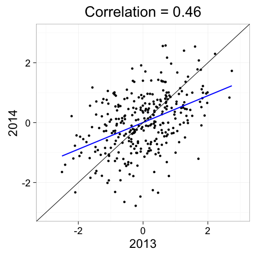

### Regression Fallacy

Regression prediction are:

\[ \frac{Y - 255}{32} = 0.46 \left( \frac{X - 261}{23}\right) \]

Regression to average is expected! There are no “jitters” or “jinx”.

### Correlation is not causation

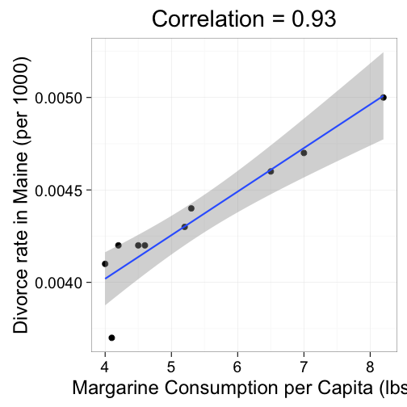

More [here](http://tylervigen.com/spurious-correlations).

### Do Bases on Ball predict runs ?

Bases on balls (BB) and runs ® correlate at the team level:

```r
Teams %>% filter(yearID > 1961 & G==162) %>%
  lm(R ~ BB, data = .) %>%
  tidy(conf.int = TRUE) %>%
  select(term, estimate, std.error)
```

```
         term estimate std.error
1 (Intercept)  360.050    18.135
2          BB    0.675     0.034
```

### BB confounded with HR

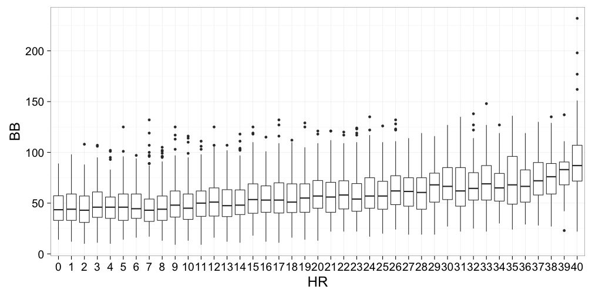

### What to do?

So we have observed or know the following

- BB are associated with Runs
- HR cause runs
- Players that hit many HR are expensive.
- Players with many BB without many HR are not that expensive.

Should we search for players with few HR but many BB?

What if the association between BB and R is completely explained by HR?

### Assessment

One way we can answer this question is by keeping HR fixed and examining the relationship within the strata.

We can't perform this analysis on a single year, because there are not enough teams to obtain strata with more than one or two teams. Instead we will combine all data years since 1961.

Start by creating a data set with R, BB and HR for every team from 1961 to today. What is the correlation between each of the three pairs.

### Assessment

One way to eliminate the the possibility the the BB effect on runs is driven by the confounding with HR is to keep HRs fixed and then examine the relationship. Give a confidence interval for the effect of BB on R for teams with 120-130 HRs. Make a plot to see if the Consider only teams from 1961 and beyond.

Compare to the coefficient when we don't stratify.

### Assessment

Now let's see if this holds for other strata.

Here is an example of how you can use functions `quantile` and `cut` to assign each team to a strata like this

```r
x <- rnorm(100)
qs <- quantile(x, prob=seq(0,1,.2))
group <- cut(x, qs, include.lowest = TRUE)
table(group)
```

You this idea to make a scatter plot of R versus BB for 10 HR strata. Hint: use `facet_wrap`

### Assessment

While the BB effect was certainly lower than before we controlled for HR, but it appears to be there. To check more formally we can fit a linear model to each strata.

### Multivariate Model

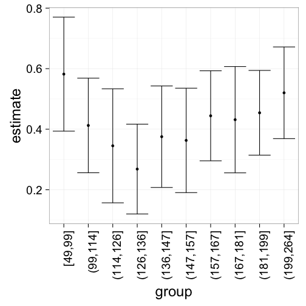

### Multivariate Model

\[ \mbox{Runs} = \beta_0 + \beta_{BB} \mbox{BB} + \beta_{HR}{HR} + \varepsilon \]

We can fit this model like this:

```r
Teams %>%
  filter(yearID >= 1961 & G==162) %>%
  lm(R~BB+HR, data=.) %>%
  tidy %>% select(term, estimate, std.error)
```

```
         term estimate std.error
1 (Intercept)  283.613   13.1562
2          BB    0.408    0.0256
3          HR    1.472    0.0471
```

### Diagnostic Plots

We can check residual plots:

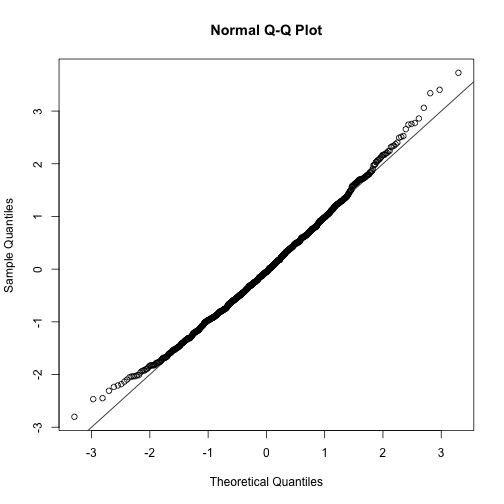

### Diagnostic Plots

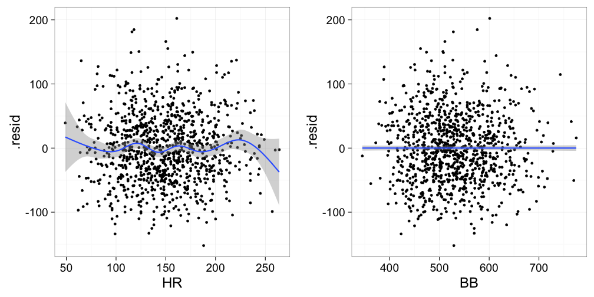